# Dataset Exploration

## Setting path

```r
library(dplyr)
```

```r
library(ggplot2)
library(reshape2)
```

```r
setwd("C:/Users/Innova/Downloads/data")
getwd()
```

```
## [1] "C:/Users/Innova/Downloads/data"
```

```r
files <- list.files(pattern = "*.csv")
```

** In the above process, we have set the path to the folder containing all the data files.

## Combining Files

```r
my_filter = function(x){
  tmp_data <- read.csv(x, header=T, stringsAsFactors = TRUE,na.strings = c("NA","#DIV/0!",""))[,-3]
  filter(tmp_data,Country.or.Area %in% c("Argentina", "Algeria","Australia", "Angola", "Brazil", "Canada", "China", "France", "Germany", "India", "Indonesia", "Italy",
                                         "Japan", "Mexico", "Russian Federation", "Saudi Arabia", "South Africa", "United Kingdom",
                                         "Zimbabwe"))
}

myfiles_test_full = do.call(rbind, lapply(files, my_filter))
```

```r
head(myfiles_test_full)
```

```
##   Country.or.Area Year       Commodity   Flow Trade..USD. Weight..kg.
## 1         Algeria 2015 ALL COMMODITIES Import 51803071085          NA
## 2         Algeria 2015 ALL COMMODITIES Export 34795951491          NA
## 3         Algeria 2014 ALL COMMODITIES Import 58618080185          NA
## 4         Algeria 2014 ALL COMMODITIES Export 60387689304          NA
## 5         Algeria 2013 ALL COMMODITIES Import 54909973274          NA
## 6         Algeria 2013 ALL COMMODITIES Export 65998137595          NA
##   Quantity.Name Quantity
## 1   No Quantity       NA
## 2   No Quantity       NA
## 3   No Quantity       NA
## 4   No Quantity       NA
## 5   No Quantity       NA
## 6   No Quantity       NA
```

** We filtered the dataset by choosing some countries and combined all the data related to that specific countries.

## Plotting

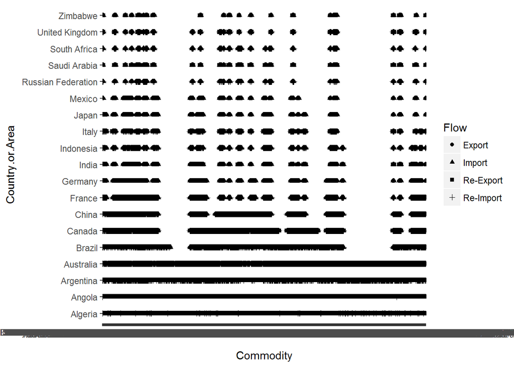

```r
library(ggplot2)

qplot(Commodity, Country.or.Area, data=myfiles_test_full, shape = Flow)
```

** The above plot, shows the flow of the commodities for every country by distinct values.

## Bar Plot

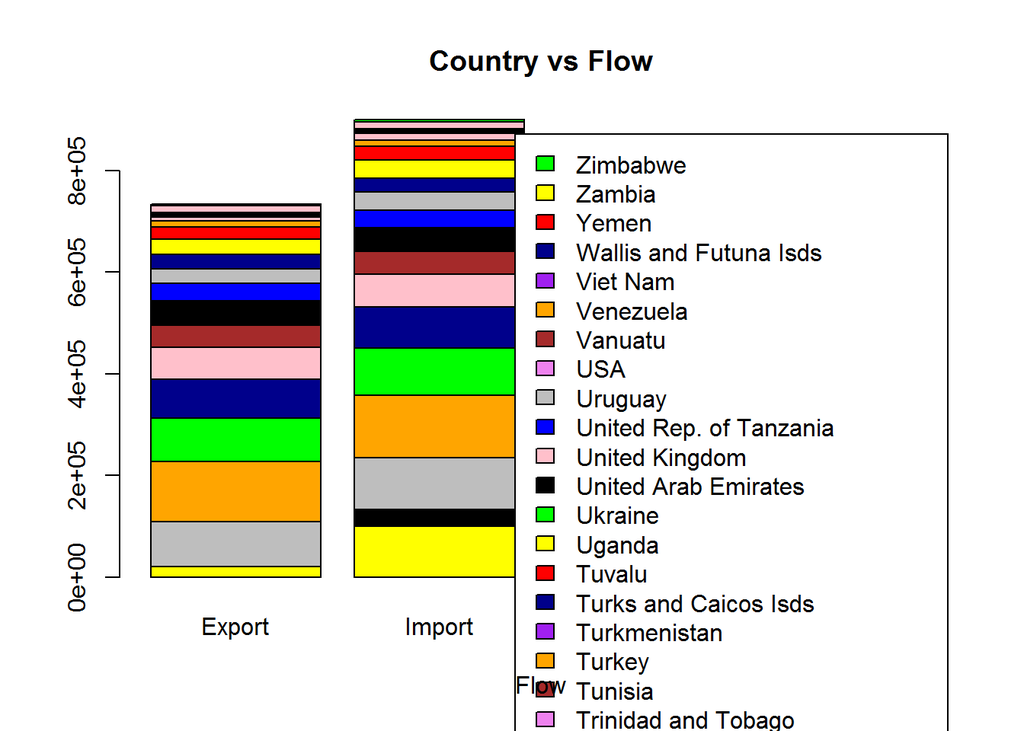

```r
barplot1 <- table(myfiles_test_full$Country.or.Area, myfiles_test_full$Flow)
barplot(barplot1, main="Country vs Flow",
        xlab="Flow", col=c("darkblue","red", "yellow", "green", "black", "pink", "blue", "grey","violet", "brown", "orange", "purple"),
        legend = rownames(barplot1))
```

** The above bar chart, gives us the amount of flow done by each country.

** Out of the export, import, reimport and re export, the ratio of import is larger.

## Filtering the data

```r
str(myfiles_test_full)
```

```
## 'data.frame':    1820875 obs. of  8 variables:
##  $ Country.or.Area: Factor w/ 208 levels "Afghanistan",..: 3 3 3 3 3 3 3 3 3 3 ...
##  $ Year           : int  2015 2015 2014 2014 2013 2013 2012 2012 2011 2011 ...
##  $ Commodity      : Factor w/ 5031 levels "ALL COMMODITIES",..: 1 1 1 1 1 1 1 1 1 1 ...
##  $ Flow           : Factor w/ 4 levels "Export","Import",..: 2 1 2 1 2 1 1 2 2 1 ...
##  $ Trade..USD.    : num  5.18e+10 3.48e+10 5.86e+10 6.04e+10 5.49e+10 ...
##  $ Weight..kg.    : num  NA NA NA NA NA NA NA NA NA NA ...
##  $ Quantity.Name  : Factor w/ 12 levels "No Quantity",..: 1 1 1 1 1 1 1 1 1 1 ...
##  $ Quantity       : num  NA NA NA NA NA NA NA NA NA NA ...
```

```r
clean_data <- data.frame(country = as.factor(myfiles_test_full$Country.or.Area),trade=myfiles_test_full$Trade..USD., year = as.factor(myfiles_test_full$Year),flow=as.factor(myfiles_test_full$Flow), Commodity = as.factor(myfiles_test_full$Commodity), weight = as.factor(myfiles_test_full$Weight..kg.))

pie_trade_country <- data.frame(country = character(), trade = integer())
levels(clean_data$country)
```

```
##   [1] "Afghanistan"                      "Albania"
##   [3] "Algeria"                          "Andorra"
##   [5] "Angola"                           "Anguilla"
##   [7] "Antigua and Barbuda"              "Argentina"
##   [9] "Armenia"                          "Aruba"
##  [11] "Australia"                        "Austria"
##  [13] "Azerbaijan"                       "Bahamas"
##  [15] "Bahrain"                          "Bangladesh"
##  [17] "Barbados"                         "Belarus"
##  [19] "Belgium"                          "Belgium-Luxembourg"
##  [21] "Belize"                           "Benin"
##  [23] "Bermuda"                          "Bhutan"
##  [25] "Bolivia (Plurinational State of)" "Bosnia Herzegovina"
##  [27] "Botswana"                         "Brazil"
##  [29] "Brunei Darussalam"                "Bulgaria"
```

[output cut: 89 more lines]

```r
for(filter_country in levels(clean_data$country)){
  filter_list = clean_data[clean_data$country == filter_country,]
  trade_amount = sum(filter_list$trade)
  pie_trade_country = rbind(pie_trade_country,data.frame(country=c(filter_country),trade=c(trade_amount)))
}
```

** In the above, we have filtered the data by taking the necessay columns and also we have added the trade by each country into a single value.

## Pie Chart

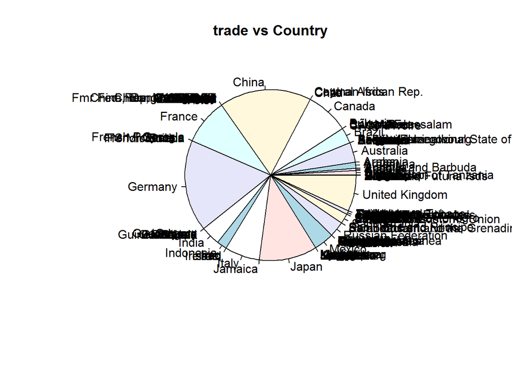

```r
pie(pie_trade_country$trade, pie_trade_country$country, main= "trade vs Country")
```

** From the above pie chart, We can conclude that Germany and China are the leading countries based upon the trade usd.

## Stacked Area Chart

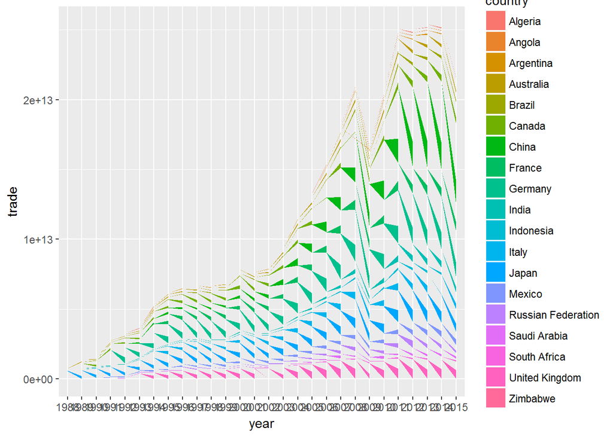

```r
library(ggplot2)
ggplot(clean_data, aes(x=year, y=trade, group=country, fill=country))+geom_area(position = "stack")
```

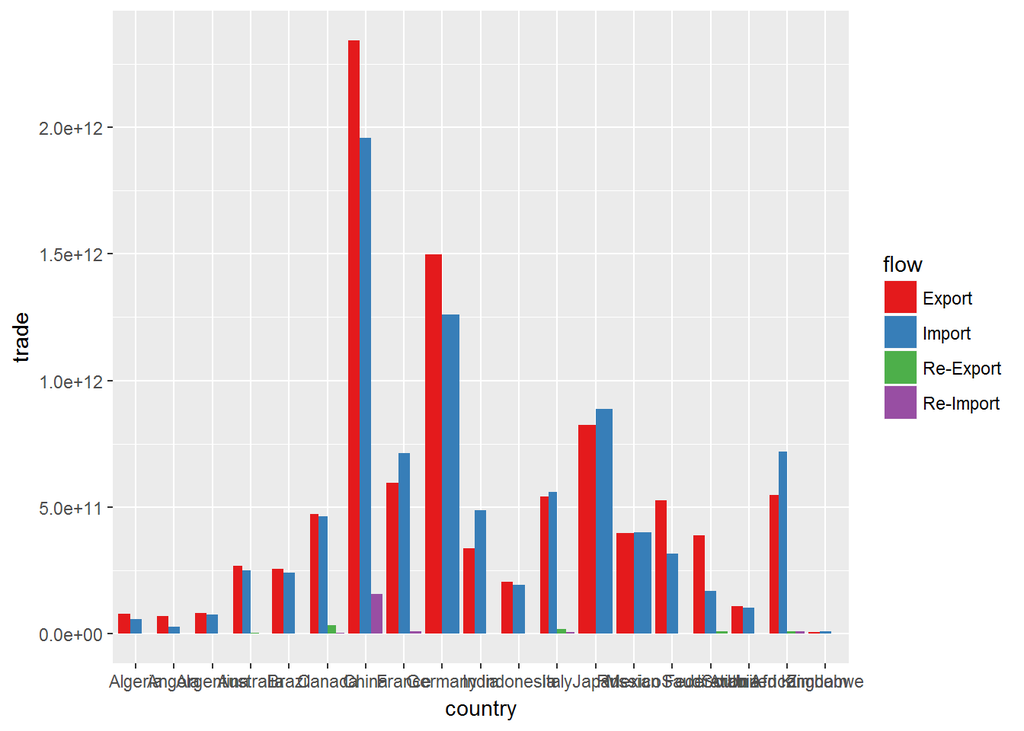

```r
library(ggplot2)
library(reshape2)

ggplot(clean_data, aes(x= country, y=trade, fill=flow))+ geom_bar(stat = "identity", position="dodge")+scale_fill_brewer(palette = "Set1")
```

** China is the leading trador of export, import and also re import.

** Zimbabwe stands last in the trade of both export and import.